# Анализ рынка видео-игр

Нам представилась возможность изучить рынок видео-игр. Интернет-магазин "Стримчик" продаёт видео-игры по всему миру для разных игровых платформ. Сейчас 2016 год и магазину необходимо решить, какие игры стоит закупать на 2017 год, чтобы повысить прибыльность. Мы поможем магазину решить, на какие игры стоит обратить внимание. Для этого изучим какие игры как продавались, данные возьмем из открытых источников, за весь период времени для всех игр, выпущенных до 2016 года включительно.  
Таким образом, перед нами стоит следующая цель:  
**Выявить закономерности, определяющие прибыльность игр**

Для достижения этой цели поставим следующие задачи:

1. Получить и обработать данные;
2. Определить актуальный временной промежуток, который позволит наиболее точно оценить закономерности;
3. Определить популярные игровые платформы;
4. Установить, игры каких жанров продаются лучше всего;
5. Оценить, есть ли зависимость прибыльности игры от оценок;
6. Составить средний портрет потребителя для каждого региона;

Таким образом, на основании полученных данных мы сможем узнать, какие игры как продаются и поможем бизнесу принять верное решение.

Приступим к изучению.

К содержанию

## Подготовка

К содержанию

Перед началом работы необходимо загрузить все необходимые библиотеки

```python
pip install matplotlib --upgrade
```

```python
import sys
try:
    import missingno as msno
except:
    !{sys.executable} -m pip install missingno;
    import missingno as msno
    pass

import warnings
warnings.filterwarnings("ignore")
import pandas as pd
import numpy as np
import seaborn as sns
from scipy import stats as st
from math import factorial
import matplotlib.pyplot as plt
from scipy.stats import binom, norm
```

Загрузим данные из файла и сохраним в датафрейм

```python
games = pd.read_csv('games.csv')
```

Посмотрим, что из себя представляет наш новый датафрейм, чтобы оценить, какие работы необходимо провести

```python
display(games.head(10))
games.info()
```

|  | Name | Platform | Year_of_Release | Genre | NA_sales | EU_sales | JP_sales | Other_sales | Critic_Score | User_Score | Rating |
| --- | --- | --- | --- | --- | --- | --- | --- | --- | --- | --- | --- |
| 0 | Wii Sports | Wii | 2006.0 | Sports | 41.36 | 28.96 | 3.77 | 8.45 | 76.0 | 8 | E |
| 1 | Super Mario Bros. | NES | 1985.0 | Platform | 29.08 | 3.58 | 6.81 | 0.77 | NaN | NaN | NaN |
| 2 | Mario Kart Wii | Wii | 2008.0 | Racing | 15.68 | 12.76 | 3.79 | 3.29 | 82.0 | 8.3 | E |
| 3 | Wii Sports Resort | Wii | 2009.0 | Sports | 15.61 | 10.93 | 3.28 | 2.95 | 80.0 | 8 | E |
| 4 | Pokemon Red/Pokemon Blue | GB | 1996.0 | Role-Playing | 11.27 | 8.89 | 10.22 | 1.00 | NaN | NaN | NaN |
| 5 | Tetris | GB | 1989.0 | Puzzle | 23.20 | 2.26 | 4.22 | 0.58 | NaN | NaN | NaN |
| 6 | New Super Mario Bros. | DS | 2006.0 | Platform | 11.28 | 9.14 | 6.50 | 2.88 | 89.0 | 8.5 | E |
| 7 | Wii Play | Wii | 2006.0 | Misc | 13.96 | 9.18 | 2.93 | 2.84 | 58.0 | 6.6 | E |
| 8 | New Super Mario Bros. Wii | Wii | 2009.0 | Platform | 14.44 | 6.94 | 4.70 | 2.24 | 87.0 | 8.4 | E |
| 9 | Duck Hunt | NES | 1984.0 | Shooter | 26.93 | 0.63 | 0.28 | 0.47 | NaN | NaN | NaN |

```
<class 'pandas.core.frame.DataFrame'>
RangeIndex: 16715 entries, 0 to 16714
Data columns (total 11 columns):
 #   Column           Non-Null Count  Dtype
---  ------           --------------  -----
 0   Name             16713 non-null  object
 1   Platform         16715 non-null  object
 2   Year_of_Release  16446 non-null  float64
 3   Genre            16713 non-null  object
 4   NA_sales         16715 non-null  float64
 5   EU_sales         16715 non-null  float64
 6   JP_sales         16715 non-null  float64
 7   Other_sales      16715 non-null  float64
 8   Critic_Score     8137 non-null   float64
 9   User_Score       10014 non-null  object
 10  Rating           9949 non-null   object
dtypes: float64(6), object(5)
memory usage: 1.4+ MB
```

В нашем датафрейме есть 16715 строк в 11 колонках:

- `Name` - название игры;
- `Platform` - платформа, для которой выпущена игра;
- `Year_of_Release` - год выпуска игры;
- `Genre` - жанр игры;
- `NA_sales` - продажи в Северной Америке (миллионы проданных копий);
- `EU_sales` — продажи в Европе (миллионы проданных копий);
- `JP_sales` — продажи в Японии (миллионы проданных копий);
- `Other_sales` — продажи в других странах (миллионы проданных копий);
- `Critic_Score` — оценка критиков (максимум 100);
- `User_Score` — оценка пользователей (максимум 10);
- `Rating` — рейтинг от организации ESRB.

При беглом осмотре выявлены следующие проблемы:

- Названия столбцов в неудобном для работы регистре;
- Пропуски в столбцах;
- Неправильные типы данных:
  - Год выпуска имеет тип `float`, год должен быть целым числом
  - Оценки пользователей типа строки, должен быть `float`.

## Предварительная обработка данных

К содержанию

Ранее мы определили некоторые проблемы в данных, которые необходимо обработать, прежде чем приступать к анализу данных. Начнём с названий колонок, чтобы последующая обработка не представляла проблем

### Исправление названий колонок

К содержанию

В первую очередь необходимо привести названия всех колонок к нижнему регистру, чтобы было проще работать.

```python
games.columns = games.columns.str.lower()
games.columns
```

```
Index(['name', 'platform', 'year_of_release', 'genre', 'na_sales', 'eu_sales',
       'jp_sales', 'other_sales', 'critic_score', 'user_score', 'rating'],
      dtype='object')
```

Отлично, названия колонок приведены к нижнему регистру и нет лишних пробелов, теперь можно приступать к дальнейшей работе.

### Изменение типов данных

К содержанию

Выше мы определили несколько колонок, в которых тип данных не соответствует информации, которая хранится в них, произведем соответствующие замены:

- `year_of_release` изменим на `int`, так как год релиза не может быть дробным числом;
- `user_score` изменим на `float`, так как со строкой нельзя производить многие арифметические операции, а в колонке хранятся числа с плавающей точкой;
- В остальных колонках проблем с типом данных нет.

```python
games['year_of_release'] = games['year_of_release'].convert_dtypes() #Потому что есть пропуски
```

В колонке `user_score` есть занчения кроме числовых и Nan. Посмотрим, на значения, чтобы знать, на что их заменить.

```python
games['user_score'].unique()
```

```
array(['8', nan, '8.3', '8.5', '6.6', '8.4', '8.6', '7.7', '6.3', '7.4',
       '8.2', '9', '7.9', '8.1', '8.7', '7.1', '3.4', '5.3', '4.8', '3.2',
       '8.9', '6.4', '7.8', '7.5', '2.6', '7.2', '9.2', '7', '7.3', '4.3',
       '7.6', '5.7', '5', '9.1', '6.5', 'tbd', '8.8', '6.9', '9.4', '6.8',
       '6.1', '6.7', '5.4', '4', '4.9', '4.5', '9.3', '6.2', '4.2', '6',
       '3.7', '4.1', '5.8', '5.6', '5.5', '4.4', '4.6', '5.9', '3.9',
       '3.1', '2.9', '5.2', '3.3', '4.7', '5.1', '3.5', '2.5', '1.9', '3',
       '2.7', '2.2', '2', '9.5', '2.1', '3.6', '2.8', '1.8', '3.8', '0',
       '1.6', '9.6', '2.4', '1.7', '1.1', '0.3', '1.5', '0.7', '1.2',
       '2.3', '0.5', '1.3', '0.2', '0.6', '1.4', '0.9', '1', '9.7'],
      dtype=object)
```

Итак, у нас встречается значение `tbd`, эта аббревиатура означает `to be determined`, то есть значение будет определено позднее. Скорее всего, для выставления рейтинга недостаточно отзывов (возможно их еще не успели поставить, или это просто непопулярная игра). Для того, чтобы было удобно работать временно заменим эти значения на Nan. Потом заменим эти пропуски более логичными данными.

```python
games['user_score'] = pd.to_numeric(games['user_score'], errors='coerce')
#данным методом заменим все выбивающиеся значения на NaN
games.dtypes
```

```
name                object
platform            object
year_of_release      Int64
genre               object
na_sales           float64
eu_sales           float64
jp_sales           float64
other_sales        float64
critic_score       float64
user_score         float64
rating              object
dtype: object
```

Итак, типы данных изменены, теперь можно заняться дальнейшими "проблемами" в нашем датафрейме

### Обработка пропусков

К содержанию

Для начала посмотрим, сколько у нас пропусков и в каких они колонках

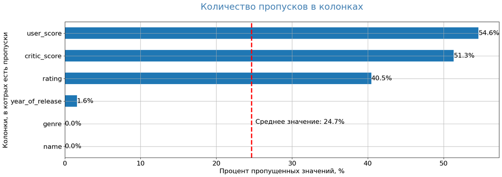

```python
games_skips = ((games.isna().mean()*100)
               .to_frame()
               .rename(columns = {0:'space'})
               .query('space > 0')
               .sort_values(by = 'space', ascending = True))
(games_skips.plot(kind = 'barh',
                  figsize = (19,6),
                  rot = 0,
                  legend = False,
                  grid=True,
                  fontsize = 16)
 .set_title('Количество пропусков в колонках' + "\n", fontsize = 22, color = 'SteelBlue'))
plt.xlabel('Процент пропущенных значений, %', fontsize = 16)
plt.ylabel('Колонки, в котрых есть пропуски', fontsize = 16)
rects = plt.barh(np.arange(len(games_skips.space)),games_skips.space,0)
plt.bar_label(rects,fontsize = 16,fmt = '%.1f%%')
plt.vlines(x = games_skips.space.mean(), ymin = -0.5, ymax = 5.5, ls='--',colors ='red', lw = 3)
plt.text(games_skips.space.mean() + 0.5, 1,
         f'Среднее значение: {round(games_skips.space.mean(),1)}%',
         fontsize = 16)
plt.show()
```

#### Удаление пропусков

К содержанию

Для начала посмотрим, что хранят строки, в которых пропуски в названиях игр и жанрах, чтобы не удалить важную информацию

```python
display(games[games['name'].isnull()])
```

|  | name | platform | year_of_release | genre | na_sales | eu_sales | jp_sales | other_sales | critic_score | user_score | rating |
| --- | --- | --- | --- | --- | --- | --- | --- | --- | --- | --- | --- |
| 659 | NaN | GEN | 1993 | NaN | 1.78 | 0.53 | 0.00 | 0.08 | NaN | NaN | NaN |
| 14244 | NaN | GEN | 1993 | NaN | 0.00 | 0.00 | 0.03 | 0.00 | NaN | NaN | NaN |

Что же, эти строки хранят информацию по играм, выпущенным в 1993 году, информация по этим играм не принесет в нашем анализе никакой пользы, так как нас интересуют актуальные данные, к тому же здесь есть пропуски в рейтинге и оценках, да и количество продаж не так велико. Так что можем смело избавиться от этих данных.  
Теперь перейдём к удалению.

```python
games = games.dropna(subset=['name','genre'])
games.isna().sum()
```

```
name                  0
platform              0
year_of_release     269
genre                 0
na_sales              0
eu_sales              0
jp_sales              0
other_sales           0
critic_score       8576
user_score         9123
rating             6764
dtype: int64
```

#### Замена пропусков в годе выпуска

К содержанию

Для начала проверим, действительно ли пропуски в этой колонке соответствуют играм, выпущенным в 2016 году

```python
games[games['year_of_release'].isna()]
```

|  | name | platform | year_of_release | genre | na_sales | eu_sales | jp_sales | other_sales | critic_score | user_score | rating |
| --- | --- | --- | --- | --- | --- | --- | --- | --- | --- | --- | --- |
| 183 | Madden NFL 2004 | PS2 | <NA> | Sports | 4.26 | 0.26 | 0.01 | 0.71 | 94.0 | 8.5 | E |
| 377 | FIFA Soccer 2004 | PS2 | <NA> | Sports | 0.59 | 2.36 | 0.04 | 0.51 | 84.0 | 6.4 | E |
| 456 | LEGO Batman: The Videogame | Wii | <NA> | Action | 1.80 | 0.97 | 0.00 | 0.29 | 74.0 | 7.9 | E10+ |
| 475 | wwe Smackdown vs. Raw 2006 | PS2 | <NA> | Fighting | 1.57 | 1.02 | 0.00 | 0.41 | NaN | NaN | NaN |
| 609 | Space Invaders | 2600 | <NA> | Shooter | 2.36 | 0.14 | 0.00 | 0.03 | NaN | NaN | NaN |
| ... | ... | ... | ... | ... | ... | ... | ... | ... | ... | ... | ... |
| 16373 | PDC World Championship Darts 2008 | PSP | <NA> | Sports | 0.01 | 0.00 | 0.00 | 0.00 | 43.0 | NaN | E10+ |
| 16405 | Freaky Flyers | GC | <NA> | Racing | 0.01 | 0.00 | 0.00 | 0.00 | 69.0 | 6.5 | T |
| 16448 | Inversion | PC | <NA> | Shooter | 0.01 | 0.00 | 0.00 | 0.00 | 59.0 | 6.7 | M |
| 16458 | Hakuouki: Shinsengumi Kitan | PS3 | <NA> | Adventure | 0.01 | 0.00 | 0.00 | 0.00 | NaN | NaN | NaN |
| 16522 | Virtua Quest | GC | <NA> | Role-Playing | 0.01 | 0.00 | 0.00 | 0.00 | 55.0 | 5.5 | T |

269 rows × 11 columns

Нет, при беглом взгляде на названия игр можно понять, что пропуски в этой колонке не зависят от того, что игра еще не была выпущена на момент получения данных. Предположить, какими значениями их можно было бы заменить - не представляется возможным, так как это приведет к смещению выборки и отразится на выборе временного промежутка для дальнейшего анализа. Однако, этих данных не так много, они составляют всего 1,6% всех данных. Поэтому смело их удалим.

```python
games = games.dropna(subset=['year_of_release'],axis=0)
```

#### Замена пропусков в оценке критиков

К содержанию

```python
games['critic_score'] = games['critic_score'].fillna(-3)
print('Количество пропусков в столбце "critic_score":', games['critic_score'].isna().sum())
```

```
Количество пропусков в столбце "critic_score": 0
```

#### Замена пропусков в оценке пользователей

К содержанию

Аналогично поступим и в этой ситуации.

```python
games['user_score'] = games['user_score'].fillna(-3)
print('Количество пропусков в столбце "user_score":', games['user_score'].isna().sum())
```

```
Количество пропусков в столбце "user_score": 0
```

#### Замена пропусков в возрастном рейтинге

К содержанию

```python
games['rating'] = games['rating'].fillna('noESRB')
print('Количество пропусков в столбце "rating":', games['rating'].isna().sum())
games.head()
```

```
Количество пропусков в столбце "rating": 0
```

|  | name | platform | year_of_release | genre | na_sales | eu_sales | jp_sales | other_sales | critic_score | user_score | rating |
| --- | --- | --- | --- | --- | --- | --- | --- | --- | --- | --- | --- |
| 0 | Wii Sports | Wii | 2006 | Sports | 41.36 | 28.96 | 3.77 | 8.45 | 76.0 | 8.0 | E |
| 1 | Super Mario Bros. | NES | 1985 | Platform | 29.08 | 3.58 | 6.81 | 0.77 | -3.0 | -3.0 | noESRB |
| 2 | Mario Kart Wii | Wii | 2008 | Racing | 15.68 | 12.76 | 3.79 | 3.29 | 82.0 | 8.3 | E |
| 3 | Wii Sports Resort | Wii | 2009 | Sports | 15.61 | 10.93 | 3.28 | 2.95 | 80.0 | 8.0 | E |
| 4 | Pokemon Red/Pokemon Blue | GB | 1996 | Role-Playing | 11.27 | 8.89 | 10.22 | 1.00 | -3.0 | -3.0 | noESRB |

Отлично, пропуски заменены настолько, насколько это возможно без внесения серьезных сдвигов в данные. Такие пропуски могли возникнуть в связи с тем, что не все игры могли быть оценены:

- Недостаточно продано, никто ещё не играл;
- Игра достаточно старая, а тогда не особо было распространено выставлять оценки;
- Может какие-то игры просто еще не успели выйти на момент 2016 года;
- Нет данных в открытом источнике.

Пропуски в возрастном рейтинге могли возникнуть по следующим причинам:

- Опять же, игра слишком старая;
- Производитель не стал обращаться в ESRB и платить за оценку;
- Игра выпущена в стране, где оценка производится не по ESRB (действует в основном только в Америке и Канаде)

Теперь необходимо проверить, есть ли повторяющиеся строки в нашем датафрейме.

### Обработка дубликатов

К содержанию

Для начала проверим, есть ли явные дубликаты в таблице

```python
print('Количество явных дубликатов в таблице:', games.duplicated().sum())
```

```
Количество явных дубликатов в таблице: 0
```

Отлично, проверим неявные дубликаты в следующих столбцах:

- `platform` - могут быть ошибки в написании названий, потому что мы не знаем кто вносил данные
- `genre` - также могут быть ошибки в написании
- `rating` - кроме ошибок в написании могут быть устаревшие обозначения рейтинга
- колонку `name` тоже стоило бы проверить, но трудно проверить более 10 тысяч записей вручную, несмотря на то, что игры могут повторяться, так как выходят на разные платформы. Плюс есть большое количество игр с повторяющимися названиями, которые означают сиквелы/приквелы и придется потратить много времени, чтобы узнать так это, или это опечатка. Так что эту колонку мы трогать не будем.

```python
games['platform'].unique()
```

```
array(['Wii', 'NES', 'GB', 'DS', 'X360', 'PS3', 'PS2', 'SNES', 'GBA',
       'PS4', '3DS', 'N64', 'PS', 'XB', 'PC', '2600', 'PSP', 'XOne',
       'WiiU', 'GC', 'GEN', 'DC', 'PSV', 'SAT', 'SCD', 'WS', 'NG', 'TG16',
       '3DO', 'GG', 'PCFX'], dtype=object)
```

В названиях платформ не встречается неявных дубликатов, это всё названия существующих игровых приставок и платформ.

```python
games['genre'].unique()
```

```
array(['Sports', 'Platform', 'Racing', 'Role-Playing', 'Puzzle', 'Misc',
       'Shooter', 'Simulation', 'Action', 'Fighting', 'Adventure',
       'Strategy'], dtype=object)
```

В названия жанров тоже не закралось никаких ошибок и опечаток, это все существующие жанры игр.

```python
games['rating'].unique()
```

```
array(['E', 'noESRB', 'M', 'T', 'E10+', 'K-A', 'AO', 'EC', 'RP'],
      dtype=object)
```

Здесь также нет никаких аномальных значений.

Проведем проверку неполных дубликатов. Для этого приведём значения колонки `name` к нижнему регистру (потому что в остальных категориальных колонках нет неявных дубликатов, как мы выяснили выше), а затем проверим, есть ли дубликаты по колонкам `name, platform и year_of_release`, возможно одну и ту же игру записали дважды. И сразу удалим эти дубликаты если они были.

```python
games['name'] = games['name'].str.lower()
print('Количество неполных дубликатов:', games.duplicated(subset=['name','platform','year_of_release','genre']).sum())
display(games[games[['name','platform','year_of_release']].duplicated() == True])
games = games.drop_duplicates(subset=['name','platform','year_of_release'], keep='first')
print('Количество неполных дубликатов после удаления:',
      games.duplicated(subset=['name','platform','year_of_release','genre']).sum())
```

```
Количество неполных дубликатов: 1
```

|  | name | platform | year_of_release | genre | na_sales | eu_sales | jp_sales | other_sales | critic_score | user_score | rating |
| --- | --- | --- | --- | --- | --- | --- | --- | --- | --- | --- | --- |
| 16230 | madden nfl 13 | PS3 | 2012 | Sports | 0.0 | 0.01 | 0.0 | 0.0 | 83.0 | 5.5 | E |

```
Количество неполных дубликатов после удаления: 0
```

Мы проверили наличие явных дубликатов, неявных дубликатов и неполных дубликатов, а также обработали все возможные дубликаты. Теперь можно приступить к следующему шагу - добавить данные для последующего анализа.

### Добавление данных

К содержанию

Для более полной оценки наших данных добавим колонку, в которой будет хранится общее число продаж в миллионах проданных копий. Для этого сложим все продажи по разным регионам.

```python
games['total_sales'] = games[['na_sales','eu_sales','jp_sales','other_sales']].sum(axis=1)
games.head()
```

|  | name | platform | year_of_release | genre | na_sales | eu_sales | jp_sales | other_sales | critic_score | user_score | rating | total_sales |
| --- | --- | --- | --- | --- | --- | --- | --- | --- | --- | --- | --- | --- |
| 0 | wii sports | Wii | 2006 | Sports | 41.36 | 28.96 | 3.77 | 8.45 | 76.0 | 8.0 | E | 82.54 |
| 1 | super mario bros. | NES | 1985 | Platform | 29.08 | 3.58 | 6.81 | 0.77 | -3.0 | -3.0 | noESRB | 40.24 |
| 2 | mario kart wii | Wii | 2008 | Racing | 15.68 | 12.76 | 3.79 | 3.29 | 82.0 | 8.3 | E | 35.52 |
| 3 | wii sports resort | Wii | 2009 | Sports | 15.61 | 10.93 | 3.28 | 2.95 | 80.0 | 8.0 | E | 32.77 |
| 4 | pokemon red/pokemon blue | GB | 1996 | Role-Playing | 11.27 | 8.89 | 10.22 | 1.00 | -3.0 | -3.0 | noESRB | 31.38 |

### Вывод

К содержанию

Обращение к открытым источникам это основной метод сбора интересующих данных, однако, такие данные не всегда являются полными и правдивыми. В случае со старыми играми, а также еще не вышедшими играми нет возможности собрать полные данные. Однако вместо оставления пропусков можно было воспользоваться индикаторными значениями (как мы и сделали) и оставить документацию (но мы живем не в идеальном мире). К тому же, необходимо также с осторожностью выбирать метод получения информации, потому что в случае с ручным отбором данных неизбежно можно наткнуться на ошибки случайного характера, которые тоже будет трудно обработать.  
В конкретном случае пропуски носят скорее всего полностью независимый характер и обусловлены банальным отсутствием интересующих данных. Так как данные необходимо собирать также из разных источников, это неминуемо может привести к наложениям и ошибкам, так как не существует единого для всех образца заполнения данных.

Перейдем к исследовательскому анализу данных

## Исследовательский анализ данных

К содержанию

### Количество выпущенных игр по годам

К содержанию

Рассмотрим, в какие годы выпускалось больше всего игр, для этого построим гистограмму.

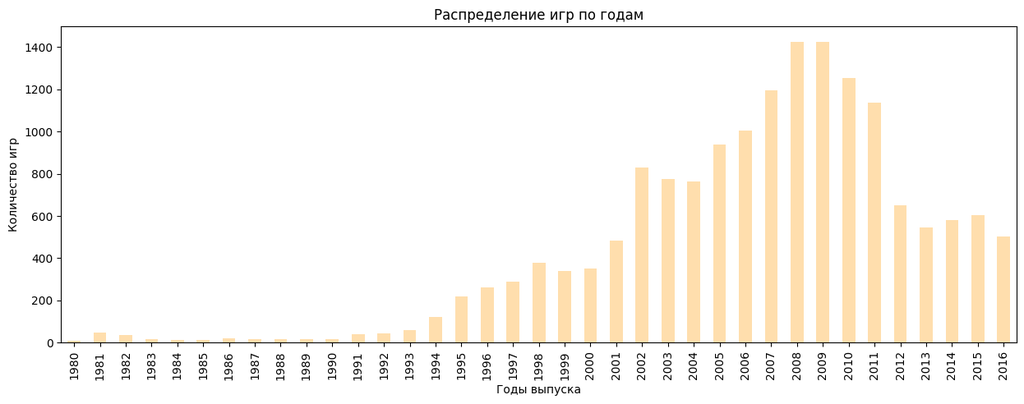

```python
(games
 .groupby('year_of_release').count()
 .plot(kind='bar',
       title='Распределение игр по годам',
       xlabel='Годы выпуска',
       ylabel='Количество игр',
       color='navajowhite',
       legend=False,
       figsize=(15,5)
      )
);
```

- До 1994 года выпускалось менее 100 игр каждый год. Это связано с тем что:
  - На рынке игр преимущественно были японские приставки, которые мало кто мог себе позволить (если судить по странам СНГ);
  - Не так масштабно было развито производство игр как сейчас;
- В 1994 начался скачок производства игр, так как начали набирать популярность домашние компьютеры, развивались технологии, появлялись более удобные и мощные среды для разработки;
- С 2002 года новый резкий скачок, появляются доступные коммерческие игровые движки, что приводит к росту числа игр;
- С 2005 года происходит увеличение популярности компьютеров, они появляются практически в каждом доме, появляются новые мощные игровые приставки, начинается гонка за популярность;
- Пик выпуска игр приходится на 2008-2009 годы;
- Спад после 2009 года связан с развитием мобильных технологий, повышением цен на игровые компьютеры и приставки, а также, возможно с мировым экономическим кризисом.
- С 2012 года активно начали набирать популярность мобильные игры, онлайн игры и социальные сети. Так что разработчики направили свой фокус в эту сторону.

### Данные разных платформ

К содержанию

#### Количество выпущенных игр по платформам

К содержанию

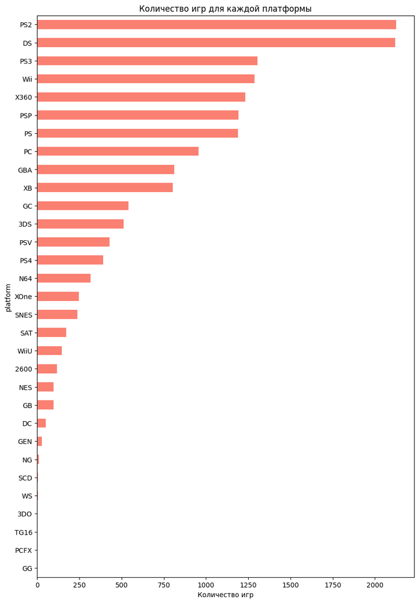

```python
(games
 .groupby('platform')['total_sales'].count()
 .sort_values()
 .plot(kind='barh',
       position = 0.5,
       title='Количество игр для каждой платформы',
       xlabel='Игровая платформа',
       figsize=(10,15),
       legend=False,
       color='salmon'
      )
);
plt.xlabel('Количество игр')
plt.show()
```

Исходя из нашего графика больше всего игр было сделано для платформ PS2 и Nintendo DS. За ними идут PS3, Wii и X360. Стационарный компьютер только на 8 месте по количеству выпущенных игр, но это не удивительно, потому что PC разработан в первую очередь не для игр. Разработчики отдавали предпочтение консолям.  
Меньше всего игр было сделано на старые японские приставки.

#### Популярность приставок

К содержанию

Теперь оценим для каких платформ продавалось больше всего игр и составим топ-платформ, для которых будем проводить дальнейший анализ.

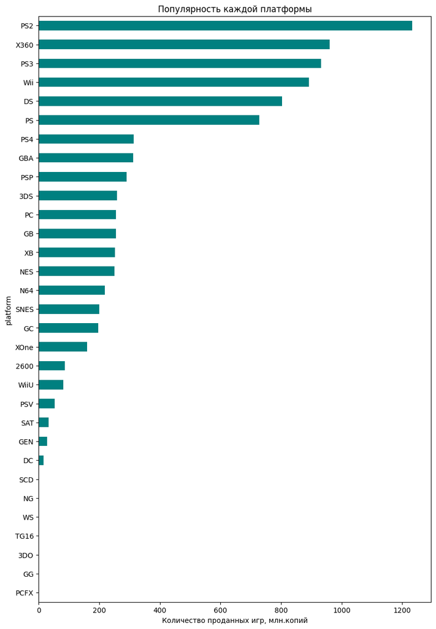

```python
(games
 .groupby('platform')['total_sales'].sum()
 .sort_values()
 .plot(kind='barh',
       position = 0.5,
       title='Популярность каждой платформы',
       xlabel='Игровая платформа',
       figsize=(10,15),
       legend=False,
       color='teal'
      )
);
plt.xlabel('Количество проданных игр, млн.копий')
plt.show()
```

А здесь картина совершенно иная, количество разработанных игр не значит качество. Хотя, это не распространяется на консоль PS2, оно и не удивительно, это одна из самых популярных и продвинутых консолей для своего времени.  
Можно выделить топ-6 приставок:

- PS2;
- X360;
- PS3;
- Wii;
- DS;
- PS.

Как и ожидалось, это основные "гиганты" производства консолей: Sony, Nintendo и Microsoft, который в своё время решил присоединиться к волне популярности приставок и ассоциироваться не только с рабочими программами для ПК.

Будем в дальнейшем рассматривать только эти консоли, потому что они больше всего выделяются на фоне остальных консолей (с отрывом более чем в 400 млн копий). Для этого создадим новый датафрейм, в который будут входить только данные для этих консолей.

```python
#Создадим список с названиями консолей
top_platform = ['PS2','X360','PS3','Wii','DS','PS']
#Создадим новый датафрейм, в который будут входить только данные по этим консолям
top_games = games.query('platform in @top_platform')
top_games.head()
```

|  | name | platform | year_of_release | genre | na_sales | eu_sales | jp_sales | other_sales | critic_score | user_score | rating | total_sales |
| --- | --- | --- | --- | --- | --- | --- | --- | --- | --- | --- | --- | --- |
| 0 | wii sports | Wii | 2006 | Sports | 41.36 | 28.96 | 3.77 | 8.45 | 76.0 | 8.0 | E | 82.54 |
| 2 | mario kart wii | Wii | 2008 | Racing | 15.68 | 12.76 | 3.79 | 3.29 | 82.0 | 8.3 | E | 35.52 |
| 3 | wii sports resort | Wii | 2009 | Sports | 15.61 | 10.93 | 3.28 | 2.95 | 80.0 | 8.0 | E | 32.77 |
| 6 | new super mario bros. | DS | 2006 | Platform | 11.28 | 9.14 | 6.50 | 2.88 | 89.0 | 8.5 | E | 29.80 |
| 7 | wii play | Wii | 2006 | Misc | 13.96 | 9.18 | 2.93 | 2.84 | 58.0 | 6.6 | E | 28.91 |

#### Срок жизни платформ

К содержанию

Оценим, в какие годы были популярны приставки из топ-6 и оценим, как долго в среднем "живут" приставки

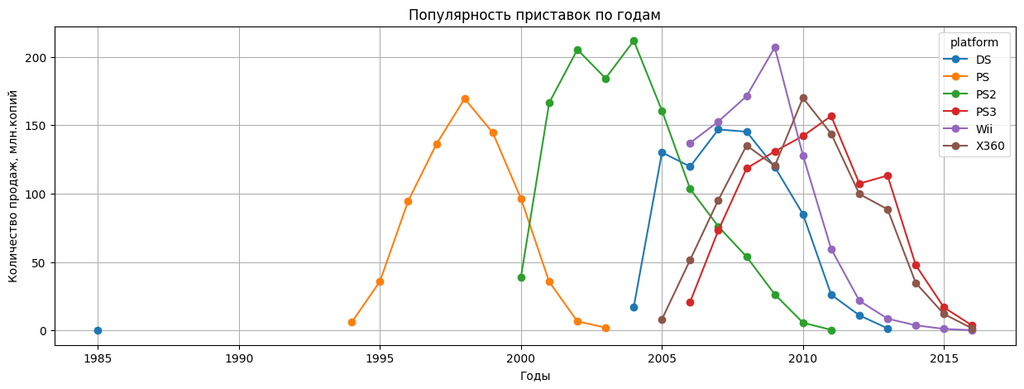

```python
(top_games
 .pivot_table(index='year_of_release', columns='platform', aggfunc={'total_sales':'sum'})
 .plot(y='total_sales',
       kind='line',
       style='o-',
       grid=True,
       figsize=(15,5),
       title='Популярность приставок по годам',
       xlabel='Годы',
       ylabel='Количество продаж, млн.копий',
      )
);
```

Исходя из данных, которые мы получили - среднее "время жизни" приставки составляет `10 лет`, дальше их сменяют обновленные и улучшенные версии, потому что появляется более мощное "железо", более продвинутые игровые движки. Да и игроки становятся всё требовательнее и чтобы оставаться на плаву в этой "гонке", необходимо соответствовать.

У платформы DS видна аномалия - игра вышла в 1985 году, при условии, что приставка вышла в 2004 году. Посмотрим, что это за выброс и много ли их и решим, что с этим делать.

```python
display(games[(games['platform']=='DS') & (games['year_of_release']==1985)])
```

|  | name | platform | year_of_release | genre | na_sales | eu_sales | jp_sales | other_sales | critic_score | user_score | rating | total_sales |
| --- | --- | --- | --- | --- | --- | --- | --- | --- | --- | --- | --- | --- |
| 15957 | strongest tokyo university shogi ds | DS | 1985 | Action | 0.0 | 0.0 | 0.02 | 0.0 | -3.0 | -3.0 | noESRB | 0.02 |

```python
games.drop(15957)
```

|  | name | platform | year_of_release | genre | na_sales | eu_sales | jp_sales | other_sales | critic_score | user_score | rating | total_sales |
| --- | --- | --- | --- | --- | --- | --- | --- | --- | --- | --- | --- | --- |
| 0 | wii sports | Wii | 2006 | Sports | 41.36 | 28.96 | 3.77 | 8.45 | 76.0 | 8.0 | E | 82.54 |
| 1 | super mario bros. | NES | 1985 | Platform | 29.08 | 3.58 | 6.81 | 0.77 | -3.0 | -3.0 | noESRB | 40.24 |
| 2 | mario kart wii | Wii | 2008 | Racing | 15.68 | 12.76 | 3.79 | 3.29 | 82.0 | 8.3 | E | 35.52 |
| 3 | wii sports resort | Wii | 2009 | Sports | 15.61 | 10.93 | 3.28 | 2.95 | 80.0 | 8.0 | E | 32.77 |
| 4 | pokemon red/pokemon blue | GB | 1996 | Role-Playing | 11.27 | 8.89 | 10.22 | 1.00 | -3.0 | -3.0 | noESRB | 31.38 |
| ... | ... | ... | ... | ... | ... | ... | ... | ... | ... | ... | ... | ... |
| 16710 | samurai warriors: sanada maru | PS3 | 2016 | Action | 0.00 | 0.00 | 0.01 | 0.00 | -3.0 | -3.0 | noESRB | 0.01 |
| 16711 | lma manager 2007 | X360 | 2006 | Sports | 0.00 | 0.01 | 0.00 | 0.00 | -3.0 | -3.0 | noESRB | 0.01 |
| 16712 | haitaka no psychedelica | PSV | 2016 | Adventure | 0.00 | 0.00 | 0.01 | 0.00 | -3.0 | -3.0 | noESRB | 0.01 |
| 16713 | spirits & spells | GBA | 2003 | Platform | 0.01 | 0.00 | 0.00 | 0.00 | -3.0 | -3.0 | noESRB | 0.01 |
| 16714 | winning post 8 2016 | PSV | 2016 | Simulation | 0.00 | 0.00 | 0.01 | 0.00 | -3.0 | -3.0 | noESRB | 0.01 |

16442 rows × 12 columns

Теперь перейдем к выбору временного промежутка для анализа. Мы уже определили, что игровые платформы живут около 10 лет. Я считаю, что стоит взять промежуток в `5` лет, так как именно в это время наблюдается спад, что отлично покажет современные реалии, отсечет все приставки, поддержка которых уже не производится и увидим новые популярные приставки. Меньше брать не имеет смысла, так как игры не так быстро делаются, как этого хотелось бы, да и не всегда слава приходит сразу. Таким образом, за отсечку возьмем `2012` год.

```python
#Создадим срез по необходимому нам временному промежутку
actual_games = games.loc[games['year_of_release'] >= 2012]
```

#### Динамика продаж в актуальный период времени

К содержанию

Найдём наиболее популярные игровые консоли для актуального промежутка времени и на их основании будем оценивать прибыльность и влияние различных факторов

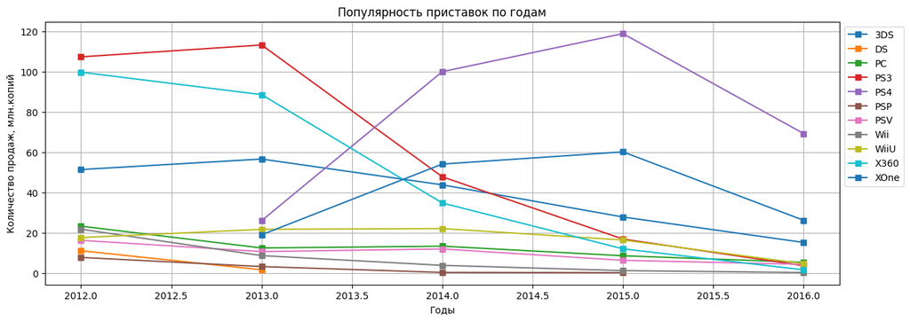

```python
(actual_games
 .pivot_table(index='year_of_release', columns='platform', aggfunc={'total_sales':'sum'})
 .plot(y='total_sales',
       kind='line',
       style='s-',
       grid=True,
       figsize=(15,5),
       title='Популярность приставок по годам',
       xlabel='Годы',
       ylabel='Количество продаж, млн.копий',
      )
);
plt.legend(bbox_to_anchor=(1,1))
plt.show()
```

На конец 2016 года изменился топ популярных приставок, теперь лидирующие позиции занимают следующие приставки:

- PS4;
- XOne;
- 3DS.

С 2014 по 2015 годы наблюдается спад популярности некоторых приставок, в основном, это те приставки, которые уже давно существуют на рынке. Новые платформы, наоборот набрали популярность к 2015 году. Впринципе, это ожидаемый результат.

В этот период можно выделить несколько наиболее "прибыльных" платформ:

- PS3,
- PS4,
- X360,
- 3DS,
- XOne.  
  Их продажи составляли более 40 млн.копий. Из гонки выбыла приставка PS, которая к этому времени просто перестала существовать (игры для платформы больше не выпускались, а новые игры она поддерживать не могла). Однако, некоторые из этих платформ уже прожили более 9 лет, а значит, они наврядли станут популярными к 2017 году.  
  Таким образом, из "прибыльных" платформ для анализа остаются только `PS4, 3DS и XOne`. Проверим общую прибыльность платформ позднее.

```python
#Зададим список прибыльных платформ
top_list=['PS4','3DS','XOne']
#Возьмем срез данных по актуальному времени для топовых платформ
top_actual_games = actual_games.query('platform in @top_list')
```

##### Глобальные продажи

К содержанию

Оценим основные характеристики глобальных продаж за указанный период времени. Для этого построим диаграмму размаха.

```
count    2885.000000
mean        0.501393
std         1.249340
min         0.010000
25%         0.040000
50%         0.120000
75%         0.430000
max        21.050000
Name: total_sales, dtype: float64
```

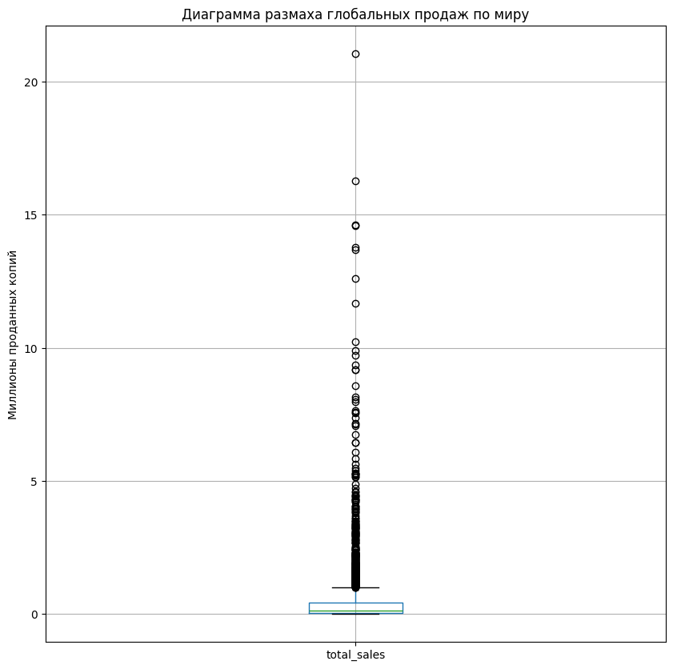

```python
display(actual_games['total_sales'].describe())
actual_games.boxplot(column='total_sales', figsize=(10,10))
plt.title('Диаграмма размаха глобальных продаж по миру')
plt.ylabel('Миллионы проданных копий')
plt.show()
```

Рассмотрим поближе график, пока есть много выбивающихся значений.

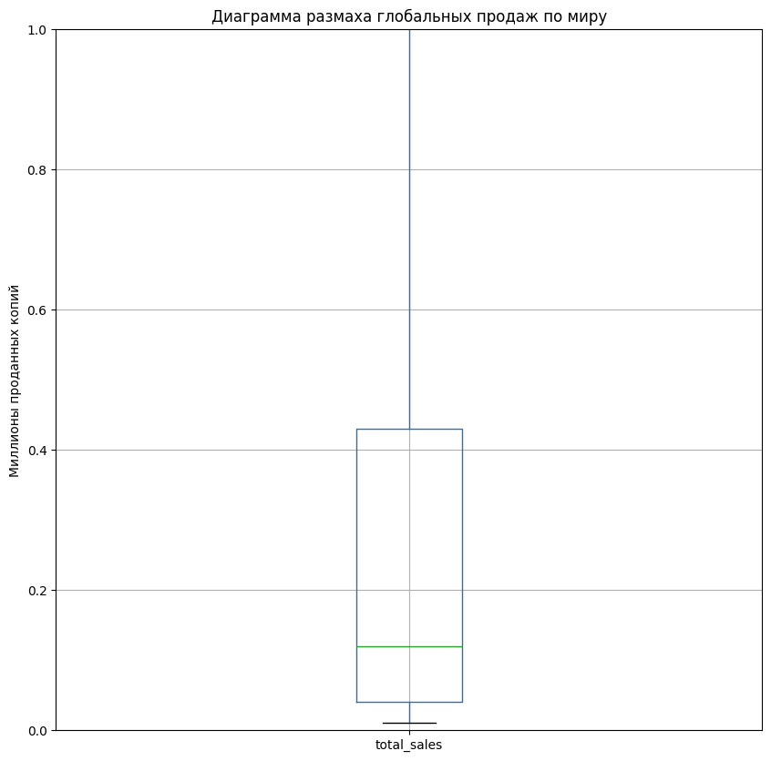

```python
actual_games.boxplot(column='total_sales', figsize=(10,10))
plt.title('Диаграмма размаха глобальных продаж по миру')
plt.ylabel('Миллионы проданных копий')
plt.ylim(0,1)
plt.show()
```

Медиана продаж в интересующий нас период составляет примерно 120 тысяч проданных копий и стремится к минимуму. В среднем за этот период продается от 40 до 430 тысяч копий. Это связано с общей тенденцией к спаду продаж в целом, а также с тем, что данные за последний год не самые точные (некоторые игры еще не вышли). Максимально за это время был продан 21 миллион копий, но на фоне общей тенденции это выглядит как аномалия, хотя на самом деле это мог быть просто очень прибыльный период, когда вышли основные платформы и самые популярные игры для них.

##### Продажи по платформам

К содержанию

Теперь оценим, что же с глобальными продажами по платформам. Мы уже знаем, что основная часть продаж будет менее 1 миллиона копий, поэтому для наглядности сразу зададим минимальные границы для наших диаграмм размаха.

| platform | count | mean | std | min | 25% | 50% | 75% | max |
| --- | --- | --- | --- | --- | --- | --- | --- | --- |
| 3DS | 396.0 | 0.491439 | 1.387161 | 0.01 | 0.0400 | 0.11 | 0.3125 | 14.60 |
| DS | 31.0 | 0.404839 | 1.439245 | 0.01 | 0.0200 | 0.05 | 0.1850 | 8.06 |
| PC | 250.0 | 0.250600 | 0.494640 | 0.01 | 0.0300 | 0.08 | 0.2400 | 5.14 |
| PS3 | 492.0 | 0.586951 | 1.464113 | 0.01 | 0.0500 | 0.20 | 0.6100 | 21.05 |
| PS4 | 392.0 | 0.801378 | 1.609456 | 0.01 | 0.0600 | 0.20 | 0.7300 | 14.63 |
| PSP | 173.0 | 0.064682 | 0.071296 | 0.01 | 0.0200 | 0.03 | 0.0900 | 0.36 |
| PSV | 411.0 | 0.119659 | 0.203011 | 0.01 | 0.0200 | 0.05 | 0.1200 | 1.96 |
| Wii | 54.0 | 0.655000 | 1.165447 | 0.01 | 0.0625 | 0.18 | 0.6875 | 6.76 |
| WiiU | 147.0 | 0.559116 | 1.058836 | 0.01 | 0.0800 | 0.22 | 0.5250 | 7.09 |
| X360 | 292.0 | 0.810068 | 1.712069 | 0.01 | 0.1000 | 0.31 | 0.8700 | 16.27 |
| XOne | 247.0 | 0.645020 | 1.036139 | 0.01 | 0.0600 | 0.22 | 0.6850 | 7.39 |

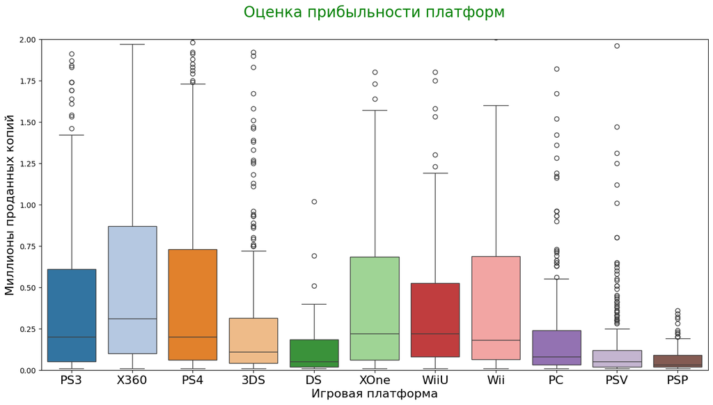

```python
display(actual_games.groupby('platform')['total_sales'].describe())
plt.figure(figsize=(16,8))
sns.boxplot(data=actual_games,
            x='platform',
            y='total_sales',
            orient='v',
            palette='tab20',
           )
plt.title('Оценка прибыльности платформ'+'\n', fontsize=20, color='green')
plt.xlabel('Игровая платформа', fontsize=16)
plt.ylabel('Миллионы проданных копий', fontsize=16)
#Выведем значение медианы продаж
#plt.hlines(y = actual_games['total_sales'].mean(), xmin = -0.5, xmax = 10.5, ls='--',colors ='green', lw = 2)
plt.xticks(fontsize=16)
plt.ylim(0,2)
plt.show()
```

Можно заметить, что для всех приставок медиана продаж стремится к минимуму, что не удивительно и подтверждает теорию о том, что игры на приставках становятся менее популярны. Однако, мы всё равно можем выделить наиболее популярные приставки за последние пять лет:

- По медиане продаж:
  1. `X360` - 310 тысяч проданных копий;
  2. `XOne, WiiU` - 220 тысяч проданных копий;
  3. `PS3 и PS4` - 200 тысяч проданных копий;
  4. `Wii` - 180 тысяч;
  5. `3DS` - 110 тысяч;
  6. `PC, DS, PSV, PSP` - менее 100 тысяч копий.
- По среднему числу продаж:
  1. `X360` - от 100 до 870 тысяч копий;
  2. `WiiU` - от 80 до 535 тысяч копий (потому что в среднем продавалось не менее 80 тысяч копий, это хороший показатель, несмотря на то, что не более 535 тысяч копий);
  3. `PS4, XOne, Wii и PS3` - от 60 до 730 тысяч копий
  4. `3DS и PC`- от 30 до 312 тысяч копий;
  5. `DS` - 20-185 тысяч;
  6. `PSV и PSP` - 20-120 тысяч;
- По максимальному числу продаж:
  1. `PS3` - 21 миллион копий;
  2. `X360` - 16 миллионов копий;
  3. `PS4 и 3DS` - 14 миллионов копий;
  4. `DS, XOne, WiiU, Wii и PC` - 5-8 миллионов;
  5. `PSV, PSP`- менее 2 миллионов.

Самыми популярными можно отметить платформы `X360, WiiU, PS3, PS4 и XOne`, несмотря на то, что первые три уже отживают своё. Самые непопулярные платформы - портативные игровые приставки. Игры для `PC` тоже находятся где-то на уровне с портативными игровыми приставками. Хотя казалось бы, пользователи перешли к мобильным играм, но видимо, в данном случае играет важность не мобильность приставки, а тип игр и их стоимость.

#### Влияние отзывов на продажи по разным платформам

К содержанию

##### Влияние оценки критиков на глобальное число продаж в целом

К содержанию

Для начала оценим как оценки критиков в целом влияют на продажи игр.

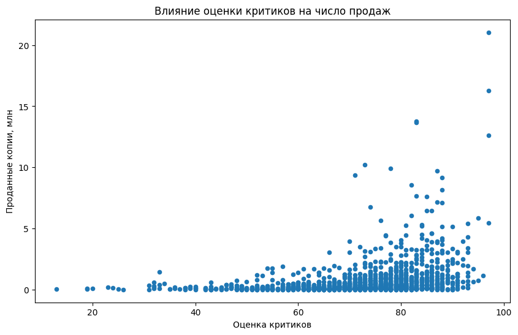

```python
(actual_games
 .query('critic_score >= 0')
 .plot(kind='scatter',x='critic_score',y='total_sales', figsize=(10,6)))
plt.title('Влияние оценки критиков на число продаж')
plt.xlabel('Оценка критиков')
plt.ylabel('Проданные копии, млн')
plt.show()
```

С увеличением среднего рейтинга количество продаж тоже растет, что не удивительно, ведь качественные игры приносят больше прибыли. Однако зависимость не такая сильная и при высоких оценках наблюдаются невысокие продажи.

##### Влияние оценки пользователей на глобальное число продаж в целом

К содержанию

Теперь оценим продажи в зависимости от отзывов пользователей

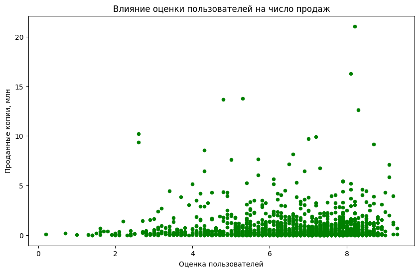

```python
(actual_games
 .query('user_score >= 0')
 .plot(kind='scatter',x='user_score',y='total_sales', figsize=(10,6), color='green'))
plt.title('Влияние оценки пользователей на число продаж')
plt.xlabel('Оценка пользователей')
plt.ylabel('Проданные копии, млн')
plt.show()
```

В данном случае наблюдаются большие продажи при низких оценках игроков. Возможно игроки более критичны, оценивают другие параметры и менее объективны в оценках. Похоже покупатели больше доверяют оценкам критиков.

Оценим корреляцию этих параметров и выясним, какой параметр влияет на продажи сильнее.

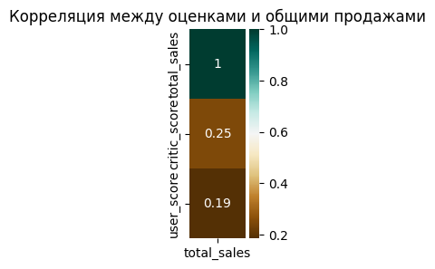

```python
#Сделаем срез только по интересующим нас данным
actual_games_corelation = actual_games[['total_sales','critic_score','user_score']]
#Зададим размер графика и название
plt.figure(figsize=(1,3))
plt.title('Корреляция между оценками и общими продажами')
#Нарисуем хитмэп для наглядности
sns.heatmap(actual_games_corelation.corr()[['total_sales']].sort_values(by='total_sales',ascending=False),
            annot=True,
            cmap='BrBG'
           );
```

Больше всего на продажи всё-таки больше влияет оценка критиков. Значит игроки больше доверяют оценкам критиков и покупают больше игр по этим оценкам. Однако, корреляция наблюдается достаточно низкая в обоих случаях. Посмотрим, что происходит с зависимостью для каждой платформы.

##### Влияние оценок на продажи по популярным платформам

К содержанию

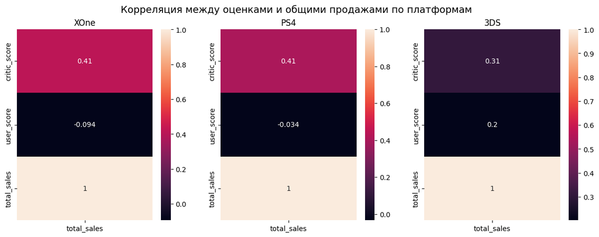

```python
#Отфильтровали - убрали "заглушки"
fd = actual_games.query('critic_score > 0 and user_score > 0')

#Функция, которая создаёт новые датафреймы для платформ
def platform_to_dataframe(platform):
    main_data = fd.query(f'platform == "{platform}"')
    main_data = main_data[['critic_score', 'user_score','total_sales']]
    return main_data

#Узнаём коэффициент корреляции
cvts = []
for i in range(len(top_list)):
    cv = 0
    cv = (platform_to_dataframe(top_list[i]).corr()[['total_sales']]).iloc[0][0]
    cvts.append(cv)
    pass

#Сортируем по коэффициенту корреляции
cv_data = pd.DataFrame(list(zip(top_list,cvts)),columns=['platform','cvts'])
cv_data = cv_data.sort_values(by=['cvts'], ascending=False)
platforms_sel = cv_data['platform'].values.tolist()

#Рисуем график
fig, axes = plt.subplots(1, len(platforms_sel), figsize=(len(platforms_sel)*5, 5))
for i in range(len(platforms_sel)):
    axes[i].set_title(platforms_sel[i])
    sns.heatmap(platform_to_dataframe(platforms_sel[i]).corr()[['total_sales']],
                annot=True,ax = axes[i])
plt.suptitle('Корреляция между оценками и общими продажами по платформам', fontsize=14)
plt.show()
```

По каждой отдельной платформе из нашего "топа" популярных игр мы тоже построили корреляцию общего числа продаж от оценок критиков и пользователей. Здесь также преобладает влияние оценок критиков, кроме платформы 3DS - здесь разница между влиянием не так явно выражена. Однако, зависимость всё ещё минимальна. Чтобы подробнее рассмотреть построим диаграмму рассеяния для каждого типа оценок по платформам.

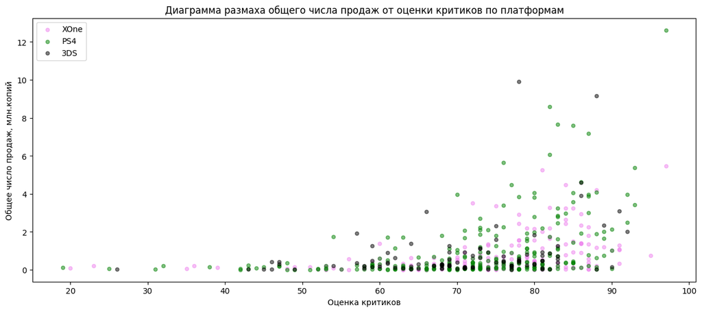

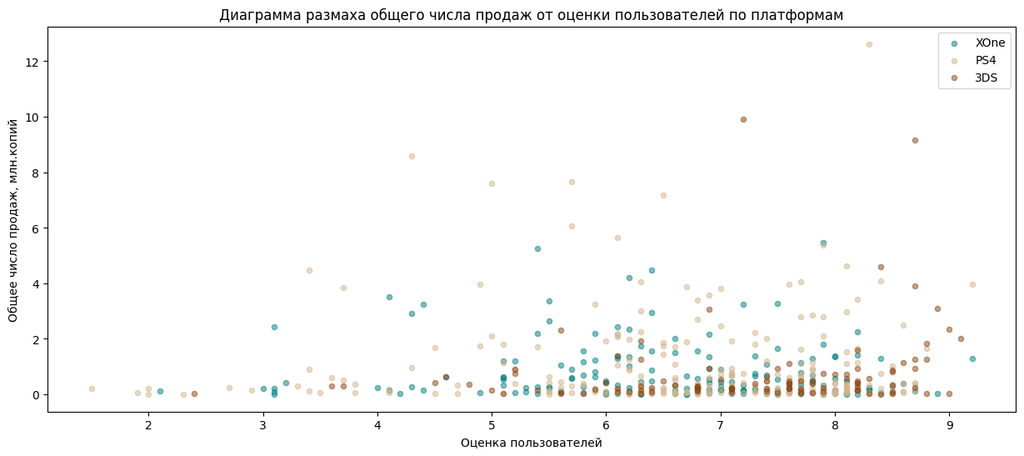

```python
fd2 = top_actual_games.query('critic_score > 0 and user_score > 0')

#По оценкам критиков
ax = fd2[fd2['platform']=='XOne'].plot(kind='scatter',
                                       x='critic_score',
                                       y='total_sales',
                                       color='violet',
                                       alpha=0.5,
                                       label='XOne',
                                       title ='Диаграмма размаха общего числа продаж от оценки критиков по платформам',
                                       figsize=(15,6)
                                      )
fd2[fd2['platform']=='PS4'].plot(kind='scatter', x='critic_score', y='total_sales', color='green', alpha=0.5, label='PS4', ax=ax)
fd2[fd2['platform']=='3DS'].plot(kind='scatter',x='critic_score', y='total_sales', color='black', alpha=0.5, label='3DS', ax=ax)
plt.xlabel('Оценка критиков')
plt.ylabel('Общее число продаж, млн.копий')
plt.show()

#По оценкам пользователей
ax2 = fd2[fd2['platform']=='XOne'].plot(kind='scatter',
                                       x='user_score',
                                       y='total_sales',
                                       color='teal',
                                       alpha = 0.5,
                                       label='XOne',
                                       title ='Диаграмма размаха общего числа продаж от оценки пользователей по платформам',
                                       figsize=(15,6)
                                      )
fd2[fd2['platform']=='PS4'].plot(kind='scatter', x='user_score', y='total_sales', color='tan', alpha=0.5, label='PS4', ax=ax2)
fd2[fd2['platform']=='3DS'].plot(kind='scatter',
                                 x='user_score',
                                 y='total_sales',
                                 color='saddlebrown',
                                 alpha=0.5,
                                 label='3DS',
                                 ax=ax2)
plt.xlabel('Оценка пользователей')
plt.ylabel('Общее число продаж, млн.копий')
plt.show()
```

Из изученых зависимостей можно сделать следующие заключения:

- На продажи больше влияет оценка критиков, чем пользователей.
- Зависимость продаж от оценок минимальна, так как и при высоких оценках наблюдаются низкие продажи, следует больше отталкиваться от других параметров (но у нас недостаточно для этого данных);

### Влияние жанров на продажи в актуальный период времени

К содержанию

Теперь рассмотрим, каких жанров больше всего и какие жанры продаются лучше всего.  
Для этого нарисуем столбачтую диаграмму с количеством и общими продажами для каждого жанра за интересующий нас период времени.

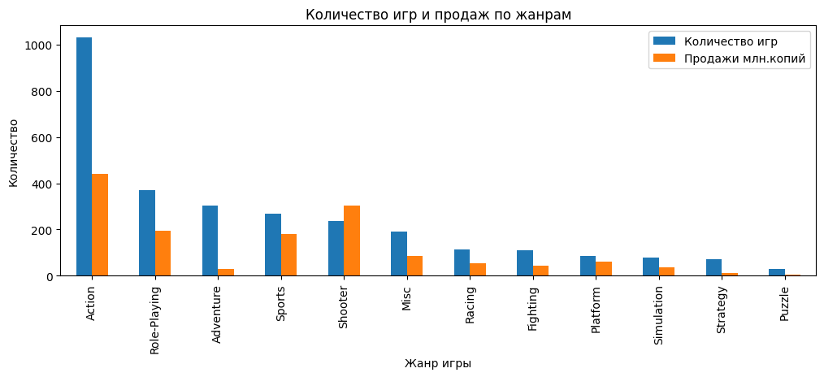

```python
(actual_games
 .groupby('genre').agg({'name':'count','total_sales':'sum'})
 .sort_values(by='name',ascending=False)
 .plot(kind='bar',
       figsize=(12,4),
       title='Количество игр и продаж по жанрам',
       xlabel='Жанр игры',
       ylabel='Количество',
      )
);
plt.legend(['Количество игр','Продажи млн.копий'])
plt.show()
```

Что можно сказать по количеству игр:

- Больше всего игр представлено в жанре `Action`- более тысячи игр
- Меньше всего игр (менее 200 игр) в жанрах `Racing, Fighting, Strategy, Platform и Puzzle`, скорее всего это связано с тем, что это игры на любителей, где надо посидеть и подумать. Кроме Файтингов, здесь скорее всего такое небольшое количество связано с тем, что этот жанр часто рассчитан на двоих игроков, а в настоящее время пользователи больше склоняются к сетевым играм

Чтобы более подробно оценить прибыльность каждого жанра, нарисуем диаграмму размаха для каждого жанра

| genre | count | mean | std | min | 25% | 50% | 75% | max |
| --- | --- | --- | --- | --- | --- | --- | --- | --- |
| Action | 1031.0 | 0.427856 | 1.166504 | 0.01 | 0.030 | 0.120 | 0.3900 | 21.05 |
| Adventure | 302.0 | 0.097450 | 0.208237 | 0.01 | 0.020 | 0.030 | 0.0775 | 1.66 |
| Fighting | 109.0 | 0.408165 | 0.910385 | 0.01 | 0.060 | 0.130 | 0.3600 | 7.55 |
| Misc | 192.0 | 0.442917 | 1.081047 | 0.01 | 0.030 | 0.120 | 0.3375 | 9.18 |
| Platform | 85.0 | 0.717647 | 1.364413 | 0.01 | 0.090 | 0.210 | 0.6600 | 9.90 |
| Puzzle | 28.0 | 0.174643 | 0.305438 | 0.01 | 0.020 | 0.045 | 0.1025 | 1.19 |
| Racing | 115.0 | 0.465217 | 0.888664 | 0.01 | 0.050 | 0.140 | 0.4200 | 7.09 |
| Role-Playing | 370.0 | 0.521081 | 1.315937 | 0.01 | 0.060 | 0.140 | 0.4075 | 14.60 |
| Shooter | 235.0 | 1.296723 | 2.251662 | 0.01 | 0.135 | 0.440 | 1.4800 | 14.63 |
| Simulation | 80.0 | 0.439000 | 1.244500 | 0.01 | 0.030 | 0.120 | 0.3275 | 9.17 |
| Sports | 267.0 | 0.678127 | 1.137778 | 0.01 | 0.080 | 0.240 | 0.7450 | 8.58 |
| Strategy | 71.0 | 0.187887 | 0.271976 | 0.01 | 0.030 | 0.080 | 0.2500 | 1.67 |

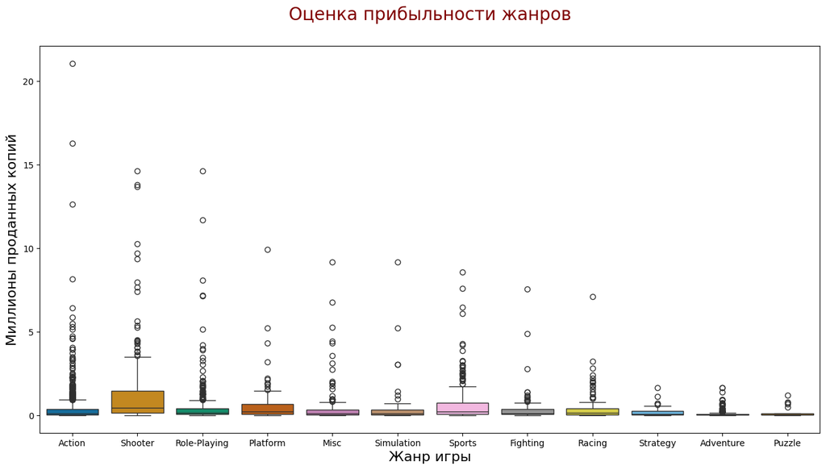

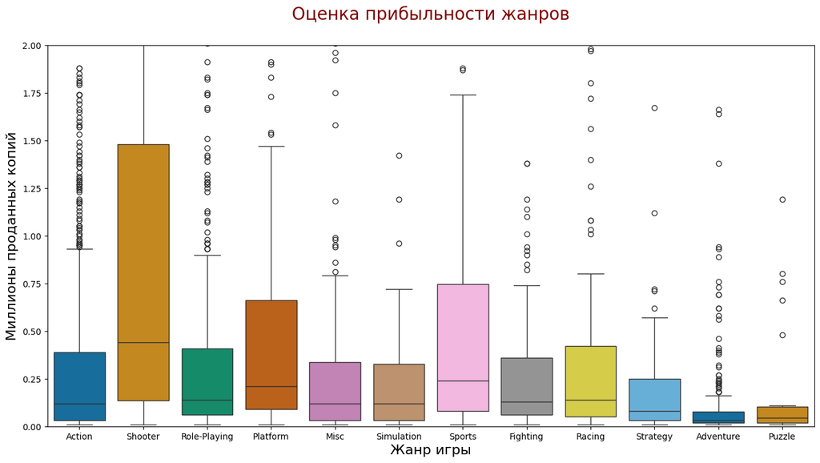

```python
#Выведем таблицу со статистикой для жанров
display(actual_games.groupby('genre')['total_sales'].describe())

#Нарисуем графики
#с выбросами
plt.figure(figsize=(16,8))
sns.boxplot(data=actual_games,
            x='genre',
            y='total_sales',
            orient='v',
            palette='colorblind',
           );
plt.title('Оценка прибыльности жанров'+'\n', fontsize=20, color='maroon')
plt.xlabel('Жанр игры', fontsize=16)
plt.ylabel('Миллионы проданных копий', fontsize=16);
plt.show()

#Без выбросов
plt.figure(figsize=(16,8))
sns.boxplot(data=actual_games,
            x='genre',
            y='total_sales',
            orient='v',
            palette='colorblind',
           );
plt.title('Оценка прибыльности жанров'+'\n', fontsize=20, color='maroon')
plt.xlabel('Жанр игры', fontsize=16)
plt.ylabel('Миллионы проданных копий', fontsize=16);
plt.ylim(0,2)
plt.show()
```

### Вывод

К содержанию

## Портрет пользователей каждого региона

К содержанию

Теперь оценим, какие закономерности в продаже игр присутствуют среди пользователей каждого региона (Северная Америка, Европа, Япония). Для этого, для пользователей каждого из представленных регионов определим:

- Самые популярные платформы (топ-5)
- Самые популярные жанры (топ-5)
- Влияет ли рейтинг ESRB на продажи в отдельном регионе?

### Популярные платформы

К содержанию

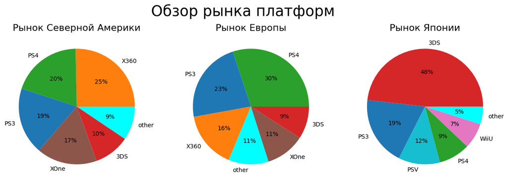

```python
#search_value = 'platform'

#Создадим функцию, потому что нам это нужно проделать несколько раз с разными параметрами
def plot_pie_bf(search_value, title_value):
    # Начальная фильтрация данных
    region = actual_games[[search_value,'na_sales','eu_sales','jp_sales']].reset_index()
    region = region.drop(columns=['index'])
    # Разделяем данные на три отдельных датафрейма, по каждому из интересующих регионов
    region_na = region.drop(columns=['eu_sales', 'jp_sales'])
    region_eu = region.drop(columns=['na_sales', 'jp_sales'])
    region_jp = region.drop(columns=['eu_sales', 'na_sales'])


    def format_regions(region_df,region):
        region_sr = region_df.groupby(search_value)[region].agg('sum')
        region_sr = region_sr.sort_values(ascending=False)
#Отрезаем и суммируем в отдельной переменной все платформы после 5 популярных
        other_regions_sum = region_sr.iloc[6:].sum()
#Завершаем форматирование и добавляем новый элемент и индексом other, каждый для своего региона
        region_sr = region_sr.iloc[:5]
        region_sr = (region_sr.add(pd.Series([other_regions_sum], index = ['other']),fill_value=0)
                     .sort_values(ascending=False))
        return region_sr
 #Создаем массив для хранения уникальных цветов, чтобы графики красились единобразно
    clr = []
    for i in range(len(region_na[search_value].unique().tolist())):
        clr.append(f'C{i}')
        pass
    # Цвета храним в словаре, из которого будем вызывать пиписковым включением
    clrs = dict(zip(region_na[search_value].unique().tolist(),clr))
    # Добавляем отдельный ключ для other, которого нет в значениях выше
    clrs['other'] = 'cyan'



    # Рисуем график
    fig, axes = plt.subplots(1, 3, figsize=(15, 5))

    (format_regions(region_na,'na_sales')
     .plot.pie(ax = axes[0],
     legend=False,
     autopct='%1.0f%%',
     ylabel='',
     colors=[clrs[key] for key in format_regions(region_na,'na_sales').index.tolist()]))
    axes[0].set_title('Рынок Северной Америки',fontsize = 16)


    (format_regions(region_eu,'eu_sales')
     .plot.pie(ax = axes[1],
     legend=False,
     autopct='%1.0f%%',
     ylabel='',
     colors=[clrs[key] for key in format_regions(region_eu,'eu_sales').index.tolist()]))
    axes[1].set_title('Рынок Европы',fontsize = 16)

    (format_regions(region_jp,'jp_sales')
     .plot.pie(ax = axes[2],
     legend=False,
     autopct='%1.0f%%',
     ylabel='',
     colors=[clrs[key] for key in format_regions(region_jp,'jp_sales').index.tolist()]))
    axes[2].set_title('Рынок Японии',fontsize = 16)

    plt.suptitle(f'Обзор рынка {title_value}',fontsize = 25)
    plt.show()
    pass

plot_pie_bf('platform', 'платформ')
```

На момент последних 5 лет, самой популярной платформой является `X360`, а в Европе больше предпочитают `PS4`. Однако, так как `X360` уже отслужила 10 лет и её можно опустить, то можно считать, что вкусы пользователей Северной Америки и Европы схожи (почти идентичны). В Японии же преобладают платформы отечественного производства - в топе только `Nintendo и PlayStation`. К тому же, можно отметить, что в Японии больше предпочтение отдаётся портативным консолям (`3DS`).

### Популярные жанры

К содержанию

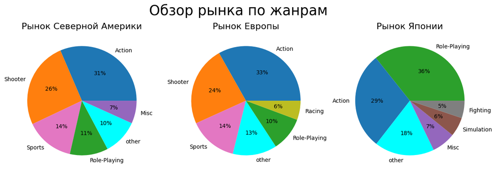

```python
plot_pie_bf('genre','по жанрам')
```

В жанрах же, пользователи Северной Америки и Европы в основном сходятся во мнениях - в топ-3 самых продаваемых игр входят игры жанров `Action, Shooter и Sports`. Здесь больше любят динамичные игры, требующие развития координации (скорости реакции, внимания) и скорости реакции. В Японии же, основное предпочтение отдают играм жанра `RPG`, то есть здесь больше любят погружаться в игру и отыгрывать роль (почти как проживать другую жизнь), но таже и экшн-игры, и игры смешанных жанров.

### Влияние рейтинга ESRB

К содержанию

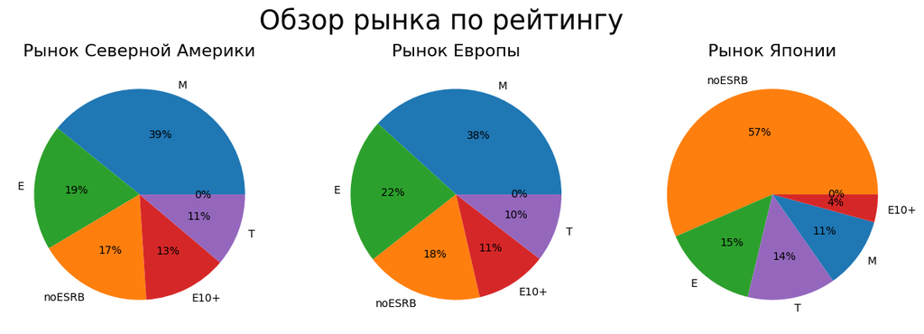

```python
plot_pie_bf('rating','по рейтингу')
```

### Вывод

К содержанию

## Проверка гипотез

К содержанию

### Одинаковые ли рейтинги платформ Xbox One и PC.

К содержанию

Для того, чтобы проверить данную гипотезу, необходимо из нашей генеральной совокупности (датафрейма) получить две выборки - срезы данных, где будет храниться информация только по интересующим нас игровым платформам. Будем использовать t-тест для сравнения средних двух независимых выборок. В качестве нулевой гипотезы примем:

- Среднее пользовательских рейтингов Xbox One `равно` среднему пользовательских рейтингов PC

Альтернативная гипотеза будет звучать следующим образом:

- Среднее пользовательских рейтингов Xbox One `не равно` среднему пользовательских рейтингов PC.

Используем двустороннюю альтернативную гипотезу, так как, мы не можем точно с уверенностью сказать, среднее оценок для какой платформы может быть больше/меньше. Тем более, что производитель данных платформ предусмотрел кросс-платформенность своих выпускаемых игр (игра с Xbox может запускаться на PC, но наоборот - вряд ли). Чтобы точно увидеть, есть ли различия в выборках, уровень значимости зададим `0.01`. Дисперсию примем не равной, так как выборки сокрее всего будут разного размера. Анализ будем проводить на промежутке времени с 2013 года, потому что именно в этот момент на рынки вышла платформа `Xbox One`.

Приступим к сравнению

```python
#Создаём выборки
xone_games = actual_games.query('platform == "XOne" and user_score >= 0')
pc_games = actual_games.query('platform == "PC" and user_score >= 0 and year_of_release >= 2013')
#Задаём уровень значимости
alpha = 0.01
#Проводим t-тест
results = st.ttest_ind(xone_games['user_score'],
                       pc_games['user_score'],
                       alternative='two-sided',
                       equal_var=False
                      )
#Выведем на экран значение p-value
print(f'Вероятность правдоподобности нулевой гипотезы (p-value): {results.pvalue}')
#Проверяем p-value
if results.pvalue < alpha:
    print('Среднее пользовательских рейтингов для PC больше')
else:
    print('Средние пользовательских рейтингов для платформ равны')
```

```
Вероятность правдоподобности нулевой гипотезы (p-value): 0.14759594013430463
Средние пользовательских рейтингов для платформ равны
```

Что же, средние значения пользовательских рейтингов для этих двух платформ равны, возможно на это действительно повлияла возможность играть в одну и ту же игру сразу на обеих платформах, а может просто у пользователей Microsoft схожие вкусы.

### Отличаются ли рейтинги игр в жанрах Action и Sports.

К содержанию

Как и в предыдущем случае, будем сравнивать среднее двух выборок. У нас снова выборки разных размеров, так как игр жанра Action выпустили гораздо больше.

- Нулевая гипотеза: средние двух выборок `равны`
- Альтернативная гипотеза: среднее выборки Action `не равно` среднему выборки Sports

Итак, наша цель установить, отличается ли среднее пользовательских рейтингов. Снова прибегнем к двустороннему t-тесту для несвязанных выборок. Критерии возьмем те же самые, что и в предыдущем случае, так как выборки разные и мы точно не знаем, в какой выборке средние оценки пользователей могут быть выше, так как при том, что игр `Action` выпустили больше, более стабильное число продаж всё же у жанра `Sports`. К тому же у этих жанров могут быть совершенно разные пользователи, так как это очень специфичные жанры и не факт, что любители экшн-игр, когда-нибудь попробуют игры жанра спорт.

```python
#Создаём выборки
action_games = actual_games.query('genre == "Action" and user_score >= 0')
sports_games = actual_games.query('genre == "Sports" and user_score >= 0')
#Задаём уровень значимости
alpha = 0.01
#Проводим t-тест
results = st.ttest_ind(action_games['user_score'],
                       sports_games['user_score'],
                       alternative='two-sided',
                       equal_var=False
                      )
#Выведем на экран значение p-value
print(f'Вероятность правдоподобности нулевой гипотезы (p-value): {results.pvalue}')
#Проверяем p-value
if results.pvalue < alpha:
    print('Средние пользовательских рейтингов для жанров не равны')
else:
    print('Средние пользовательских рейтингов для жанров равны')
```

```
Вероятность правдоподобности нулевой гипотезы (p-value): 5.989458066467418e-20
Средние пользовательских рейтингов для жанров не равны
```

Нулевую гипотезу следует отвергнуть, так как вероятность того, что средние пользовательских рейтингов двух отличающихся жанров с разной аудиторией и разными критериями оценок, ничтожно мала.

## Вывод

К содержанию

1.Мы изучили данные о продажах игр за период с 1980 по 2016 годы и выяснили следующее:

- Популярность игр начала расти с 1994 года;
- Пик популярности был достигнут в 2008-2009 годах;
- С 2010 по настоящее время (2016 год) наблюдается спад популярности игр, что скорее всего связано с развитием мобильных технологий и социальных сетей.

2.При исследовании игровых платформ определили следующие закономерности:

- В среднем все игровые платформы "живут" около 10 лет;
- Самые популярные игровые платформы на интересующий нас промежуток времени (5 лет):
  - XOne,
  - 3DS,
  - PS4

3.Самыми прибыльными жанрами оказались - `Shooter, Sports и Platform`, это наиболее стабильно продающиеся игры.

4.На продажи игр больше всего влияют оценки критиков, чем оценки пользователей. Однако это не такая сильная зависимость и игры в основном покупаются не смотря на оценки.

5.Также необходимо принять во внимание, что в различных регионах мира предпочтения пользователей могут разительно отличаться от общей картины. Так, например, в Японии игроки предпочитают игры и платформы отечественного производства и, в отличие от Европы и Северной Америки, больше любят игры жанра RPG. А также выбирают портативные игровые консоли.

6.При сравнении платформ XOne и PC, обнаружено, что средние оценки пользователей этих платформ не имеют существенных различий, а вот к оценкам пользователей игр жанров Sports и Action стоит повнимательнее присмотреться.

7.В целом, рынок видео-игр постепенно приходит в упадок, производить игры, отвечающие потребностям пользователей становится всё затратнее, особенно с учётом быстро развивающегося "железа", платформы быстрее устаревают и пользователи предпочитают игры, в которые они могут поиграть везде, где им удобно.